# Face Image Neuralnet

This notebook will demonstrate the use of a neural network to classify face images. The classifier will attempt to distinguish between faces turning left and faces turning right. We will vary the number of nodes in the hidden layer to examine the effect on performance.

First we load the appropriate libraries:

```r
library(pixmap)
library(gdata)
```

Here are examples of the face data:

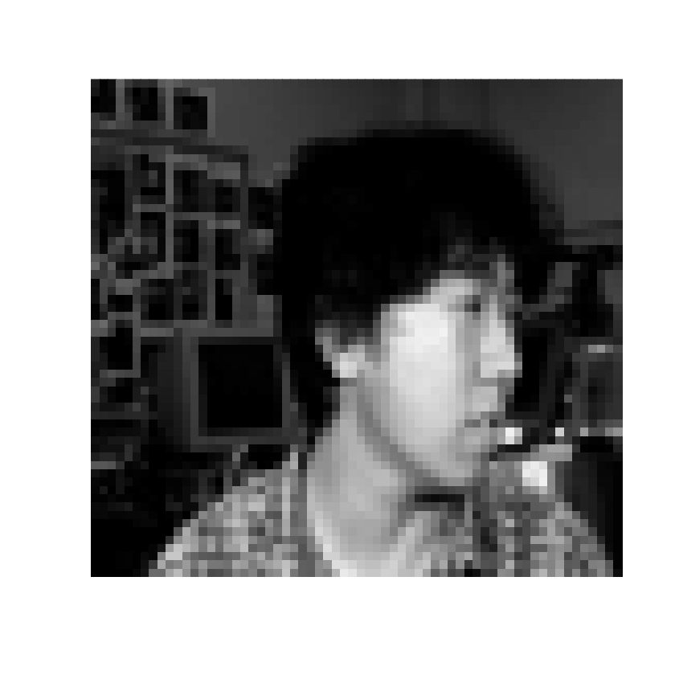

```r
left1<-read.pnm(file="Homework 4 Face Dataset/Left/left1.pgm")
plot(left1)
```

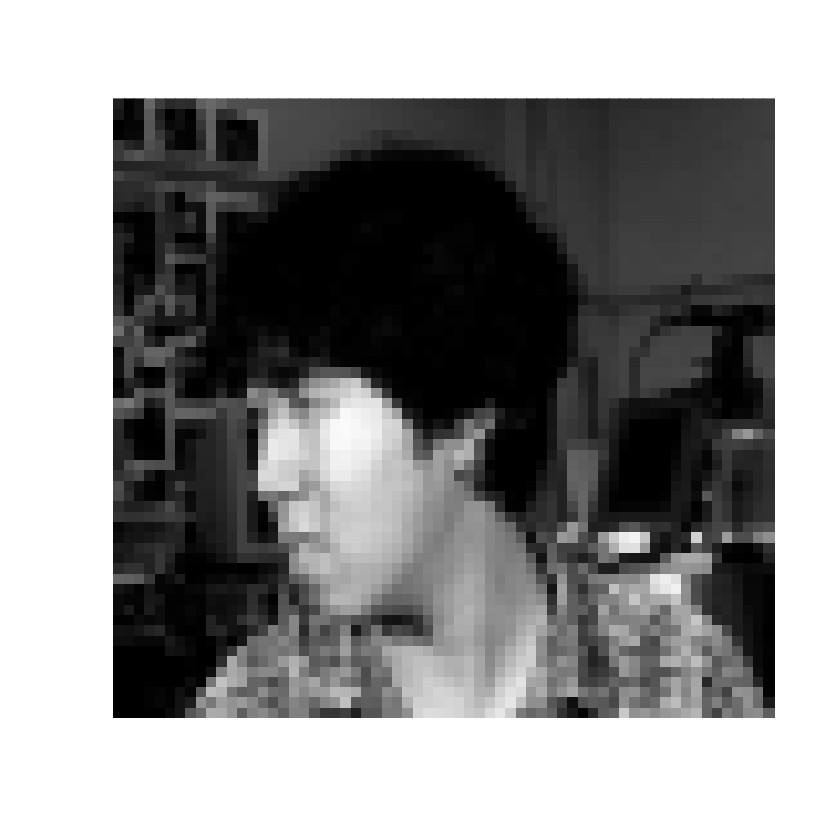

```r
right1<-read.pnm(file="Homework 4 Face Dataset/Right/right1.pgm")
plot(right1)
```

Next we train the network. We will randomize the data and then use 80% of it to train the neural network and 20% of it to test the data.

We first use the following function to load the data:

```r
loadImages <- function(pathName,fileNames, clasLabel)
{
files<-list.files(path=pathName,pattern=fileNames,all.files=T,full.name=T,no..=T)
list_of_images=lapply(files,read.pnm)
plot(list_of_images[[1]])
n.images<-length(list_of_images)
image.matrix<-list_of_images[[1]]@grey
image.vector<-unmatrix(image.matrix,byrow=T)
for(ii in 2:n.images)
{
 i.matrix<-list_of_images[[ii]]@grey
 i.vector<-unmatrix(i.matrix,byrow=T)
 image.vector<-rbind(image.vector,i.vector)
}
image.frame<-data.frame(image.vector)
n.rows<-nrow(image.frame)
class1.label<-rep(clasLabel,n.rows)
image.frame<-cbind(image.frame,class1.label)
return (image.frame)
}
```

[output not shown]

[output not shown]

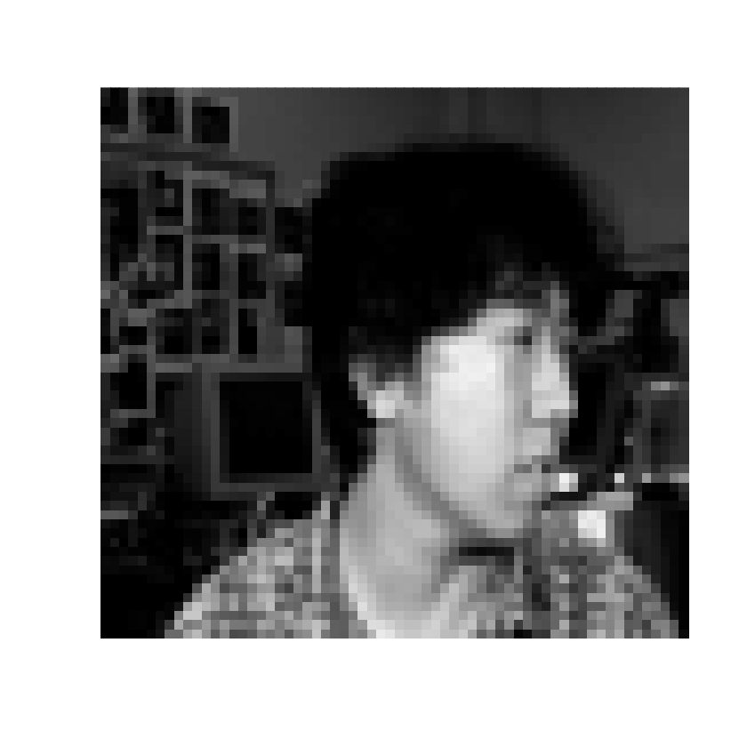

```r
left.frame <- loadImages("Homework 4 Face Dataset/Left", "left*.*", 0)
left.frame
```

[output not shown]

[output not shown]

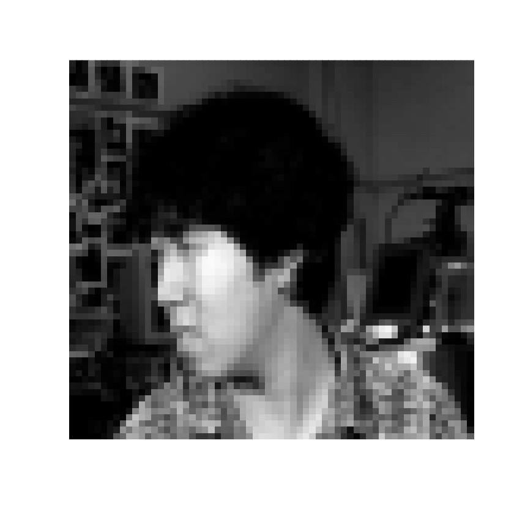

```r
right.frame<-loadImages("Homework 4 Face Dataset/Right", "right*.*", 1)
right.frame
```

```r
total.frame<-rbind(left.frame,right.frame)
total.frame
```

[output not shown]

Next we create the training and test sets:

```r
train.index<-sample(nrow(total.frame),nrow(total.frame)*0.8)
training.set<-total.frame[train.index,]
training.set
```

[output not shown]

```r
test.set<-total.frame[-train.index,]
test.set
```

|  | r1.c1 | r1.c2 | r1.c3 | r1.c4 | r1.c5 | r1.c6 | r1.c7 | r1.c8 | r1.c9 | r1.c10 | ... | r60.c56 | r60.c57 | r60.c58 | r60.c59 | r60.c60 | r60.c61 | r60.c62 | r60.c63 | r60.c64 | class1.label |
| --- | --- | --- | --- | --- | --- | --- | --- | --- | --- | --- | --- | --- | --- | --- | --- | --- | --- | --- | --- | --- | --- |
| i.vector | 0.20769231 | 0.200000000 | 0.20000000 | 0.19230769 | 0.1846154 | 0.1769231 | 0.1692308 | 0.1692308 | 0.1615385 | 0.1538462 | ... | 0.8692308 | 0.50000000 | 0.007692308 | 0.03076923 | 0.03846154 | 0.146153846 | 0.22307692 | 0.22307692 | 0.215384615 | 0 |
| i.vector.6 | 0.19841270 | 0.198412698 | 0.19047619 | 0.18253968 | 0.1746032 | 0.1746032 | 0.1666667 | 0.1587302 | 0.1587302 | 0.1507937 | ... | 0.8888889 | 0.51587302 | 0.007936508 | 0.03174603 | 0.03968254 | 0.142857143 | 0.22222222 | 0.22222222 | 0.222222222 | 0 |
| i.vector.7 | 0.24161074 | 0.228187919 | 0.22147651 | 0.21476510 | 0.2147651 | 0.2080537 | 0.2013423 | 0.2013423 | 0.1946309 | 0.1879195 | ... | 0.2617450 | 0.26845638 | 0.268456376 | 0.26845638 | 0.26174497 | 0.261744966 | 0.26174497 | 0.25503356 | 0.241610738 | 0 |
| i.vector.8 | 0.21935484 | 0.212903226 | 0.21290323 | 0.20645161 | 0.2000000 | 0.1935484 | 0.1870968 | 0.1806452 | 0.1806452 | 0.1741935 | ... | 0.2838710 | 0.27741935 | 0.264516129 | 0.25161290 | 0.23870968 | 0.225806452 | 0.21290323 | 0.20645161 | 0.200000000 | 0 |
| i.vector.21 | 0.10897436 | 0.000000000 | 0.05128205 | 0.38461538 | 0.2243590 | 0.1538462 | 0.1730769 | 0.1666667 | 0.3525641 | 0.3974359 | ... | 0.7307692 | 0.51282051 | 0.282051282 | 0.30769231 | 0.35897436 | 0.410256410 | 0.20512821 | 0.03205128 | 0.006410256 | 0 |
| i.vector.28 | 0.08759124 | 0.087591241 | 0.08759124 | 0.08759124 | 0.1021898 | 0.1897810 | 0.2189781 | 0.2116788 | 0.2116788 | 0.2116788 | ... | 0.7299270 | 0.73722628 | 0.744525547 | 0.74452555 | 0.71532847 | 0.627737226 | 0.15328467 | 0.00000000 | 0.000000000 | 0 |
| i.vector.31 | 0.21600000 | 0.296000000 | 0.24800000 | 0.24800000 | 0.2400000 | 0.2400000 | 0.2400000 | 0.2320000 | 0.2320000 | 0.2240000 | ... | 0.8640000 | 0.84800000 | 0.808000000 | 0.44800000 | 0.00000000 | 0.000000000 | 0.00000000 | 0.00000000 | 0.000000000 | 0 |
| i.vector.40 | 0.02777778 | 0.263888889 | 0.20833333 | 0.20833333 | 0.2013889 | 0.2013889 | 0.2013889 | 0.1944444 | 0.1944444 | 0.1875000 | ... | 0.8958333 | 0.88888889 | 0.888888889 | 0.88194444 | 0.83333333 | 0.173611111 | 0.00000000 | 0.00000000 | 0.000000000 | 0 |
| i.vector.43 | 0.28846154 | 0.365384615 | 0.21794872 | 0.23076923 | 0.2371795 | 0.3012821 | 0.4230769 | 0.3717949 | 0.3205128 | 0.3012821 | ... | 0.1666667 | 0.07692308 | 0.128205128 | 0.07692308 | 0.02564103 | 0.006410256 | 0.00000000 | 0.00000000 | 0.000000000 | 0 |
| i.vector.45 | 0.11464968 | 0.006369427 | 0.07006369 | 0.40764331 | 0.2356688 | 0.1656051 | 0.1847134 | 0.1783439 | 0.3757962 | 0.4140127 | ... | 0.3439490 | 0.51592357 | 0.535031847 | 0.30573248 | 0.29299363 | 0.114649682 | 0.05732484 | 0.03184713 | 0.000000000 | 0 |
| i.vector.46 | 0.10191083 | 0.006369427 | 0.05095541 | 0.37579618 | 0.2165605 | 0.1528662 | 0.1656051 | 0.1656051 | 0.3439490 | 0.3885350 | ... | 0.4840764 | 0.51592357 | 0.350318471 | 0.42038217 | 0.21656051 | 0.484076433 | 0.50318471 | 0.05095541 | 0.000000000 | 0 |
| image.vector1 | 0.11612903 | 0.006451613 | 0.05806452 | 0.40000000 | 0.2322581 | 0.1612903 | 0.1806452 | 0.1741935 | 0.3677419 | 0.4129032 | ... | 0.6645161 | 0.70967742 | 0.380645161 | 0.26451613 | 0.49032258 | 0.419354839 | 0.53548387 | 0.55483871 | 0.374193548 | 1 |
| i.vector.121 | 0.23178808 | 0.225165563 | 0.22516556 | 0.21854305 | 0.2119205 | 0.2052980 | 0.1986755 | 0.1920530 | 0.1920530 | 0.1854305 | ... | 0.2516556 | 0.21192053 | 0.172185430 | 0.35761589 | 0.31125828 | 0.317880795 | 0.31788079 | 0.31788079 | 0.317880795 | 1 |
| i.vector.141 | 0.22516556 | 0.218543046 | 0.21192053 | 0.21192053 | 0.2052980 | 0.1986755 | 0.1920530 | 0.1854305 | 0.1788079 | 0.1721854 | ... | 0.3178808 | 0.21854305 | 0.165562914 | 0.28476821 | 0.31788079 | 0.317880795 | 0.31788079 | 0.31788079 | 0.317880795 | 1 |
| i.vector.231 | 0.20491803 | 0.196721311 | 0.18852459 | 0.17213115 | 0.1721311 | 0.1639344 | 0.1639344 | 0.1557377 | 0.1475410 | 0.1393443 | ... | 0.9098361 | 0.90983607 | 0.909836066 | 0.89344262 | 0.90163934 | 0.614754098 | 0.21311475 | 0.21311475 | 0.204918033 | 1 |
| i.vector.341 | 0.02739726 | 0.273972603 | 0.21917808 | 0.21232877 | 0.2123288 | 0.2123288 | 0.2054795 | 0.1986301 | 0.1986301 | 0.1986301 | ... | 0.8150685 | 0.89726027 | 0.890410959 | 0.89041096 | 0.88356164 | 0.849315068 | 0.30136986 | 0.00000000 | 0.000000000 | 1 |
| i.vector.351 | 0.02962963 | 0.266666667 | 0.20000000 | 0.20740741 | 0.2000000 | 0.2000000 | 0.1925926 | 0.2000000 | 0.1925926 | 0.1851852 | ... | 0.9037037 | 0.90370370 | 0.903703704 | 0.90370370 | 0.89629630 | 0.888888889 | 0.60740741 | 0.00000000 | 0.000000000 | 1 |
| i.vector.421 | 0.28846154 | 0.275641026 | 0.27564103 | 0.26923077 | 0.2564103 | 0.2500000 | 0.2435897 | 0.2371795 | 0.2307692 | 0.2243590 | ... | 0.1282051 | 0.12820513 | 0.096153846 | 0.12179487 | 0.09615385 | 0.192307692 | 0.30128205 | 0.29487179 | 0.301282051 | 1 |
| i.vector.431 | 0.30128205 | 0.378205128 | 0.23076923 | 0.23717949 | 0.2435897 | 0.3141026 | 0.4358974 | 0.3846154 | 0.3333333 | 0.3141026 | ... | 0.2500000 | 0.23717949 | 0.134615385 | 0.08974359 | 0.03205128 | 0.006410256 | 0.00000000 | 0.00000000 | 0.000000000 | 1 |
| i.vector.481 | 0.20325203 | 0.195121951 | 0.18699187 | 0.18699187 | 0.1788618 | 0.1788618 | 0.1707317 | 0.1626016 | 0.1626016 | 0.1544715 | ... | 0.9186992 | 0.67479675 | 0.008130081 | 0.03252033 | 0.04065041 | 0.138211382 | 0.21138211 | 0.21138211 | 0.211382114 | 1 |

Next we train the classifiers, varying the number of hidden nodes:

```r
library(neuralnet)
myform <- as.formula(paste('class1.label ~ ',paste(names(training.set[!names(training.set) %in% 'class1.label']), collapse = ' + ')))
face.classifier.3 <- neuralnet(myform, training.set, hidden = 3, rep=100, linear.output = FALSE, threshold = 0.1)
summary(face.classifier.3)
```

```
                    Length  Class      Mode
call                      7 -none-     call
response                 80 -none-     numeric
covariate            307200 -none-     numeric
model.list                2 -none-     list
err.fct                   1 -none-     function
act.fct                   1 -none-     function
linear.output             1 -none-     logical
data                   3841 data.frame list
exclude                   0 -none-     NULL
net.result              100 -none-     list
weights                 100 -none-     list
generalized.weights     100 -none-     list
startweights            100 -none-     list
result.matrix       1153000 -none-     numeric
```

```r
face.classifier.5 <- neuralnet(myform, training.set, hidden = 5, rep=100, linear.output = FALSE, threshold = 0.1)
summary(face.classifier.5)
```

```
                    Length  Class      Mode
call                      7 -none-     call
response                 80 -none-     numeric
covariate            307200 -none-     numeric
model.list                2 -none-     list
err.fct                   1 -none-     function
act.fct                   1 -none-     function
linear.output             1 -none-     logical
data                   3841 data.frame list
exclude                   0 -none-     NULL
net.result              100 -none-     list
weights                 100 -none-     list
generalized.weights     100 -none-     list
startweights            100 -none-     list
result.matrix       1921400 -none-     numeric
```

```r
face.classifier.7 <- neuralnet(myform, training.set, hidden = 7, rep=100, linear.output = FALSE, threshold = 0.1)
summary(face.classifier.7)
```

```
                    Length  Class      Mode
call                      7 -none-     call
response                 80 -none-     numeric
covariate            307200 -none-     numeric
model.list                2 -none-     list
err.fct                   1 -none-     function
act.fct                   1 -none-     function
linear.output             1 -none-     logical
data                   3841 data.frame list
exclude                   0 -none-     NULL
net.result              100 -none-     list
weights                 100 -none-     list
generalized.weights     100 -none-     list
startweights            100 -none-     list
result.matrix       2689800 -none-     numeric
```